# Practical Machine Learning Course Project

*Adam Chudziak*

## Summary

This project is concerned about predicting the type of physical activity performed by the subject wearing special sensors. It falls in broad category of research regarding wearable senors such as *Fitbit* or *Nike FuelBand*. Five different types of barbell lifts were performed. The data comes from accelerometers on the belt, forearm, arm, and dumbell of 6 participants. The goal is to construct a model for prediction of the type of barbell lift performed. More information about the data can be found on [this website](http://groupware.les.inf.puc-rio.br/har) (section Weight Lifting Exercise Data set).

We proposed some Machine Learning models for the task. The models were trained on 60% of the training data set, while remaining 40% served as a validation set. Random forest framework achieved satisfactory accuracy on the testing set and hence we propose a model based on this methodology.

## Data

Data used in this study can be found [here](https://d396qusza40orc.cloudfront.net/predmachlearn/pml-training.csv). Also twenty testing cases used for evaluation can be found [here](https://d396qusza40orc.cloudfront.net/predmachlearn/pml-testing.csv). The following code downloads both data sets if they are not yet in the working directory and divides the training set into training and testing data sets.

```r
library(ggplot2)
library(caret)
library(rpart)
library(randomForest)
library(rattle)

d1url <- "http://d396qusza40orc.cloudfront.net/predmachlearn/pml-training.csv"
d2url <- "http://d396qusza40orc.cloudfront.net/predmachlearn/pml-testing.csv"
if(!file.exists("pml-training.csv")){download.file(d1url,destfile = "pml-training.csv")}
trainData <- read.csv("pml-training.csv", na.strings = c("NA",""))
if(!file.exists("pml-testing.csv")){download.file(d2url,destfile = "pml-testing.csv")}
testData <- read.csv("pml-testing.csv",na.strings = c("NA",""))

all.equal(colnames(trainData)[1:ncol(trainData)-1], colnames(testData)[1:ncol(testData)-1])
```

```
## [1] TRUE
```

```r
set.seed(579)
inTrain <- createDataPartition(trainData$classe,p=0.6,list = FALSE)
training <- trainData[inTrain,]
testing <- trainData[-inTrain,]

rm(trainData,inTrain)

str(training[,1:12])
```

```
## 'data.frame':    11776 obs. of  12 variables:
##  $ X                   : int  7 8 9 10 14 18 20 21 22 23 ...
##  $ user_name           : Factor w/ 6 levels "adelmo","carlitos",..: 2 2 2 2 2 2 2 2 2 2 ...
##  $ raw_timestamp_part_1: int  1323084232 1323084232 1323084232 1323084232 1323084232 1323084232 1323084232 1323084232 1323084232 1323084232 ...
##  $ raw_timestamp_part_2: int  368296 440390 484323 484434 576390 732306 788335 876301 892313 932285 ...
##  $ cvtd_timestamp      : Factor w/ 20 levels "02/12/2011 13:32",..: 9 9 9 9 9 9 9 9 9 9 ...
##  $ new_window          : Factor w/ 2 levels "no","yes": 1 1 1 1 1 1 1 1 1 1 ...
##  $ num_window          : int  12 12 12 12 12 12 12 12 12 12 ...
##  $ roll_belt           : num  1.42 1.42 1.43 1.45 1.42 1.55 1.59 1.6 1.57 1.56 ...
##  $ pitch_belt          : num  8.09 8.13 8.16 8.17 8.21 8.08 8.07 8.1 8.09 8.1 ...
##  $ yaw_belt            : num  -94.4 -94.4 -94.4 -94.4 -94.4 -94.4 -94.4 -94.4 -94.4 -94.3 ...
##  $ total_accel_belt    : int  3 3 3 3 3 3 3 3 3 3 ...
##  $ kurtosis_roll_belt  : Factor w/ 396 levels "-0.016850","-0.021024",..: NA NA NA NA NA NA NA NA NA NA ...
```

We created data partition into a training set of almost 12 000 observations and testing set of almost 8 thousand variables. There are 160 variables and the type of physical activity performed is stored in the last variable “classe”. Manually looking at the data set we notice that some variables have a lot of missing values. High number of predictors does not necessarily help prediction, thus we decided to get rid of variables which have missing values. We also drop first seven columns as they are not relevant for prediction

```r
toDrop <- apply(array(training),2,function(x){sum(is.na(x))>0})

toDrop[1:7] <- TRUE

training <- training[,!toDrop]
testing <- testing[,!toDrop]
testData <- testData[,!toDrop]
```

This leave us with 53 variables. The last thing is we check for variable s with low variability.

```r
nearZeroVar(training,saveMetrics = TRUE)
```

```
##                      freqRatio percentUnique zeroVar   nzv
## roll_belt             1.140977    8.53430707   FALSE FALSE
## pitch_belt            1.067227   13.70584239   FALSE FALSE
## yaw_belt              1.012903   14.45312500   FALSE FALSE
## total_accel_belt      1.079950    0.23777174   FALSE FALSE
## gyros_belt_x          1.048780    1.02751359   FALSE FALSE
## gyros_belt_y          1.148507    0.54347826   FALSE FALSE
## gyros_belt_z          1.063492    1.38417120   FALSE FALSE
## accel_belt_x          1.032653    1.32472826   FALSE FALSE
## accel_belt_y          1.179088    1.14639946   FALSE FALSE
## accel_belt_z          1.031193    2.44565217   FALSE FALSE
## magnet_belt_x         1.123810    2.45414402   FALSE FALSE
## magnet_belt_y         1.012821    2.36073370   FALSE FALSE
## magnet_belt_z         1.006969    3.52411685   FALSE FALSE
## roll_arm             45.886364   19.73505435   FALSE FALSE
## pitch_arm            80.800000   22.35054348   FALSE FALSE
## yaw_arm              29.691176   21.55230978   FALSE FALSE
## total_accel_arm       1.007380    0.54347826   FALSE FALSE
## gyros_arm_x           1.093023    5.23097826   FALSE FALSE
## gyros_arm_y           1.498328    3.04857337   FALSE FALSE
## gyros_arm_z           1.092879    1.92764946   FALSE FALSE
## accel_arm_x           1.038835    6.41983696   FALSE FALSE
## accel_arm_y           1.095588    4.45822011   FALSE FALSE
## accel_arm_z           1.078947    6.50475543   FALSE FALSE
## magnet_arm_x          1.122449   11.12432065   FALSE FALSE
## magnet_arm_y          1.056604    7.14164402   FALSE FALSE
## magnet_arm_z          1.030303   10.53838315   FALSE FALSE
## roll_dumbbell         1.094595   87.55944293   FALSE FALSE
## pitch_dumbbell        2.456790   85.46195652   FALSE FALSE
## yaw_dumbbell          1.051948   86.88009511   FALSE FALSE
## total_accel_dumbbell  1.081181    0.35665761   FALSE FALSE
## gyros_dumbbell_x      1.008357    1.95312500   FALSE FALSE
## gyros_dumbbell_y      1.305136    2.25883152   FALSE FALSE
## gyros_dumbbell_z      1.016713    1.63892663   FALSE FALSE
## accel_dumbbell_x      1.010050    3.43070652   FALSE FALSE
## accel_dumbbell_y      1.033113    3.82133152   FALSE FALSE
## accel_dumbbell_z      1.058065    3.37126359   FALSE FALSE
## magnet_dumbbell_x     1.082569    8.92493207   FALSE FALSE
## magnet_dumbbell_y     1.138889    6.94633152   FALSE FALSE
## magnet_dumbbell_z     1.000000    5.60461957   FALSE FALSE
## roll_forearm         11.242857   14.62296196   FALSE FALSE
## pitch_forearm        57.560976   20.83050272   FALSE FALSE
## yaw_forearm          14.836478   14.29177989   FALSE FALSE
## total_accel_forearm   1.121131    0.57744565   FALSE FALSE
## gyros_forearm_x       1.063898    2.38620924   FALSE FALSE
## gyros_forearm_y       1.012397    6.02921196   FALSE FALSE
## gyros_forearm_z       1.150350    2.38620924   FALSE FALSE
## accel_forearm_x       1.056604    6.59816576   FALSE FALSE
## accel_forearm_y       1.000000    8.14368207   FALSE FALSE
## accel_forearm_z       1.000000    4.66202446   FALSE FALSE
## magnet_forearm_x      1.065217   12.00747283   FALSE FALSE
## magnet_forearm_y      1.200000   15.32778533   FALSE FALSE
## magnet_forearm_z      1.000000   13.29823370   FALSE FALSE
## classe                1.469065    0.04245924   FALSE FALSE
```

It turns out that the variability of the variables left is satisfactory.

## Models

We started modelling using simple models such as decision trees and random forests. It turned out that we can achieve satisfactory accuracy using the latter and further investigation of more advanced or ensemble methods was not necessary.

### Decision Tree

The first model fitted was a decision tree.

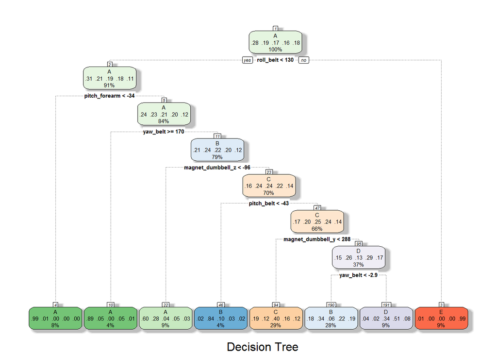

```r
set.seed(6243)

modelDecisionTree <- train(classe~., data = training, method = "rpart")
fancyRpartPlot(modelDecisionTree$finalModel, sub = "Decision Tree")
```

Unfortunately the model has very poor accuracy, even on the training data.

```r
trainingPredictDT <- predict(modelDecisionTree, newdata = training)
confusionMatrix(training$classe,trainingPredictDT)
```

```
## Confusion Matrix and Statistics
##
##           Reference
## Prediction    A    B    C    D    E
##          A 2035  601  667   39    6
##          B  331 1519  405   24    0
##          C   49  253 1382  370    0
##          D   84  736  560  550    0
##          E   35  634  409   90  997
##
## Overall Statistics
##
##                Accuracy : 0.5505
##                  95% CI : (0.5415, 0.5595)
##     No Information Rate : 0.3178
##     P-Value [Acc > NIR] : < 2.2e-16
##
##                   Kappa : 0.4353
##  Mcnemar's Test P-Value : < 2.2e-16
##
## Statistics by Class:
##
##                      Class: A Class: B Class: C Class: D Class: E
## Sensitivity            0.8031   0.4058   0.4037  0.51258  0.99402
## Specificity            0.8579   0.9054   0.9195  0.87106  0.89158
## Pos Pred Value         0.6078   0.6665   0.6728  0.28497  0.46051
## Neg Pred Value         0.9408   0.7658   0.7901  0.94688  0.99938
## Prevalence             0.2152   0.3178   0.2907  0.09112  0.08517
## Detection Rate         0.1728   0.1290   0.1174  0.04671  0.08466
## Detection Prevalence   0.2843   0.1935   0.1744  0.16389  0.18385
## Balanced Accuracy      0.8305   0.6556   0.6616  0.69182  0.94280
```

The in-sample accuracy around 55% is below satisfactory and not a good prospect for out-of the sample error.

### Random Forest

The second model fitted was a random forest model.

```r
modelRF <- randomForest(y = training$classe, x = training[,1:(ncol(training)-1)], prox=TRUE, ntree = 200)

trainingPredictRF <- predict(modelRF, newdata = training)
confusionMatrix(trainingPredictRF,training$classe)
```

```
## Confusion Matrix and Statistics
##
##           Reference
## Prediction    A    B    C    D    E
##          A 3348    0    0    0    0
##          B    0 2279    0    0    0
##          C    0    0 2054    0    0
##          D    0    0    0 1930    0
##          E    0    0    0    0 2165
##
## Overall Statistics
##
##                Accuracy : 1
##                  95% CI : (0.9997, 1)
##     No Information Rate : 0.2843
##     P-Value [Acc > NIR] : < 2.2e-16
##
##                   Kappa : 1
##  Mcnemar's Test P-Value : NA
##
## Statistics by Class:
##
##                      Class: A Class: B Class: C Class: D Class: E
## Sensitivity            1.0000   1.0000   1.0000   1.0000   1.0000
## Specificity            1.0000   1.0000   1.0000   1.0000   1.0000
## Pos Pred Value         1.0000   1.0000   1.0000   1.0000   1.0000
## Neg Pred Value         1.0000   1.0000   1.0000   1.0000   1.0000
## Prevalence             0.2843   0.1935   0.1744   0.1639   0.1838
## Detection Rate         0.2843   0.1935   0.1744   0.1639   0.1838
## Detection Prevalence   0.2843   0.1935   0.1744   0.1639   0.1838
## Balanced Accuracy      1.0000   1.0000   1.0000   1.0000   1.0000
```

The accuracy on the training set is almost 100%.

### Validation and out-of-sample error estimates

The validation of models and estimation of out-of-sample error were performed on the testing data set comprising 40% cases of the original data set.

```r
testingPredictDT <- predict(modelDecisionTree, newdata = testing)
testingPredictRF <- predict(modelRF, newdata = testing)
```

The statistics for Decision Tree model are below.

```r
confusionMatrix(testingPredictDT,testing$classe)
```

```
## Confusion Matrix and Statistics
##
##           Reference
## Prediction    A    B    C    D    E
##          A 1338  229   37   58   14
##          B  418  994  149  471  463
##          C  445  265  904  395  273
##          D   23   30  278  362   58
##          E    8    0    0    0  634
##
## Overall Statistics
##
##                Accuracy : 0.5394
##                  95% CI : (0.5283, 0.5505)
##     No Information Rate : 0.2845
##     P-Value [Acc > NIR] : < 2.2e-16
##
##                   Kappa : 0.4215
##  Mcnemar's Test P-Value : < 2.2e-16
##
## Statistics by Class:
##
##                      Class: A Class: B Class: C Class: D Class: E
## Sensitivity            0.5995   0.6548   0.6608  0.28149  0.43967
## Specificity            0.9398   0.7628   0.7873  0.94070  0.99875
## Pos Pred Value         0.7983   0.3984   0.3961  0.48202  0.98754
## Neg Pred Value         0.8551   0.9021   0.9166  0.86977  0.88784
## Prevalence             0.2845   0.1935   0.1744  0.16391  0.18379
## Detection Rate         0.1705   0.1267   0.1152  0.04614  0.08081
## Detection Prevalence   0.2136   0.3180   0.2908  0.09572  0.08183
## Balanced Accuracy      0.7696   0.7088   0.7240  0.61110  0.71921
```

The model performs poorly - accuracy of only around 53.9% on a new data set yields a very high estimate out-of-sample error of 46.1%.

The statistics for Random Forests model are below.

```r
confusionMatrix(testingPredictRF,testing$classe)
```

```
## Confusion Matrix and Statistics
##
##           Reference
## Prediction    A    B    C    D    E
##          A 2225   10    0    0    0
##          B    7 1503    7    0    0
##          C    0    5 1360   16    2
##          D    0    0    1 1269   11
##          E    0    0    0    1 1429
##
## Overall Statistics
##
##                Accuracy : 0.9924
##                  95% CI : (0.9902, 0.9942)
##     No Information Rate : 0.2845
##     P-Value [Acc > NIR] : < 2.2e-16
##
##                   Kappa : 0.9903
##  Mcnemar's Test P-Value : NA
##
## Statistics by Class:
##
##                      Class: A Class: B Class: C Class: D Class: E
## Sensitivity            0.9969   0.9901   0.9942   0.9868   0.9910
## Specificity            0.9982   0.9978   0.9964   0.9982   0.9998
## Pos Pred Value         0.9955   0.9908   0.9834   0.9906   0.9993
## Neg Pred Value         0.9988   0.9976   0.9988   0.9974   0.9980
## Prevalence             0.2845   0.1935   0.1744   0.1639   0.1838
## Detection Rate         0.2836   0.1916   0.1733   0.1617   0.1821
## Detection Prevalence   0.2849   0.1933   0.1763   0.1633   0.1823
## Balanced Accuracy      0.9975   0.9940   0.9953   0.9925   0.9954
```

Accuracy of around 99.2% gives an estimate out-of-sample error of 0.8%. This is a satisfactory accuracy so we decided to pick this predictive model.

## Closing remarks

We tested two models and the second using random forests performed satisfactory on the testing set achieving 99.2% accuracy. We used it for prediction in the 20 cases presented by the Instructor. 20 out of 20 predictions were accurate.

### Estimation of testcases

The following code was used for estimation of 20 test cases

```r
library(randomForest)
testDataPredictionRF <- predict(modelRF, newdata = testData[,1:(ncol(testData)-1)])
```